# Practico Módulo 3: Análisis Bivariado

Author

Gerardo Esteban, Gómez-Santiago

Published

January 31, 2025

## Introducción

El objetivo de este práctico es consolidar conocimiento en torno al calculo de medidas estadísticas que nos permiten afirmar si existe o no una asociación significativa entre variables.  
Para este análisis utilizaremos la base `Advertising.csv`, la cual contiene 200 observaciones de gasto en publicidad por distintos medios (TV, radio y periodico) y el valor de las ventas.

Se espera naturalmente que exista cierto grado de asociación entre el gasto en publicidad y el nivel de ventas, por lo que el objetivo es verificar cual de estos medios presenta una mayor asociación con el nivel de ventas y por lo tanto resulta más efectivo como estrategia de mercadeo.

## Pasos previos

- Limpeza del ambiente de trabajo
- Selección del directorio de trabajo
- Carga de la base de datos

```r
rm(list = ls())


getwd()
```

```
[1] "E:/Documents/Escritorio/tidyverso/tidyverso/cursoRLunes/RLunes/scripts/bases/taller3/bases"
```

```r
setwd("E:/Documents/Escritorio/tidyverso/tidyverso/cursoRLunes/RLunes/scripts/bases/taller3/bases")


base <- read.csv(file = "Advertising.csv")


library(glmtoolbox)
data("advertising")

library(tidyverse)

base %>% glimpse()
```

```
Rows: 200
Columns: 5
$ X         <int> 1, 2, 3, 4, 5, 6, 7, 8, 9, 10, 11, 12, 13, 14, 15, 16, 17, 1…
$ TV        <dbl> 230.1, 44.5, 17.2, 151.5, 180.8, 8.7, 57.5, 120.2, 8.6, 199.…
$ radio     <dbl> 37.8, 39.3, 45.9, 41.3, 10.8, 48.9, 32.8, 19.6, 2.1, 2.6, 5.…
$ newspaper <dbl> 69.2, 45.1, 69.3, 58.5, 58.4, 75.0, 23.5, 11.6, 1.0, 21.2, 2…
$ sales     <dbl> 22.1, 10.4, 9.3, 18.5, 12.9, 7.2, 11.8, 13.2, 4.8, 10.6, 8.6…
```

```r
summary(base)
```

```
       X                TV             radio          newspaper
 Min.   :  1.00   Min.   :  0.70   Min.   : 0.000   Min.   :  0.30
 1st Qu.: 50.75   1st Qu.: 74.38   1st Qu.: 9.975   1st Qu.: 12.75
 Median :100.50   Median :149.75   Median :22.900   Median : 25.75
 Mean   :100.50   Mean   :147.04   Mean   :23.264   Mean   : 30.55
 3rd Qu.:150.25   3rd Qu.:218.82   3rd Qu.:36.525   3rd Qu.: 45.10
 Max.   :200.00   Max.   :296.40   Max.   :49.600   Max.   :114.00
     sales
 Min.   : 1.60
 1st Qu.:10.38
 Median :12.90
 Mean   :14.02
 3rd Qu.:17.40
 Max.   :27.00
```

## Punto 1

Obtenga la matriz de covarianzas y de correlaciones de las cuatro variables. Resulta de particular interes conocer la correlación del gasto en públicidad de cada uno de los medios de comunicación con las ventas ¿son todos significativos? ¿Cuál presenta una asociación lineal mas fuerte?

```r
cov(base %>%
      select(-X))
```

```
                  TV     radio newspaper     sales
TV        7370.94989  69.86249 105.91945 350.39019
radio       69.86249 220.42774 114.49698  44.63569
newspaper  105.91945 114.49698 474.30833  25.94139
sales      350.39019  44.63569  25.94139  27.22185
```

```r
cor(base %>%
      select(-X))
```

```
                  TV      radio  newspaper     sales
TV        1.00000000 0.05480866 0.05664787 0.7822244
radio     0.05480866 1.00000000 0.35410375 0.5762226
newspaper 0.05664787 0.35410375 1.00000000 0.2282990
sales     0.78222442 0.57622257 0.22829903 1.0000000
```

```r
cor.test(base$TV, base$sales)
```

```
    Pearson's product-moment correlation

data:  base$TV and base$sales
t = 17.668, df = 198, p-value < 2.2e-16
alternative hypothesis: true correlation is not equal to 0
95 percent confidence interval:
 0.7218201 0.8308014
sample estimates:
      cor
0.7822244
```

```r
cor.test(base$radio, base$sales)
```

```
    Pearson's product-moment correlation

data:  base$radio and base$sales
t = 9.9208, df = 198, p-value < 2.2e-16
alternative hypothesis: true correlation is not equal to 0
95 percent confidence interval:
 0.4754954 0.6620366
sample estimates:
      cor
0.5762226
```

```r
cor.test(base$newspaper, base$sales)
```

```
    Pearson's product-moment correlation

data:  base$newspaper and base$sales
t = 3.2996, df = 198, p-value = 0.001148
alternative hypothesis: true correlation is not equal to 0
95 percent confidence interval:
 0.0924875 0.3557712
sample estimates:
     cor
0.228299
```

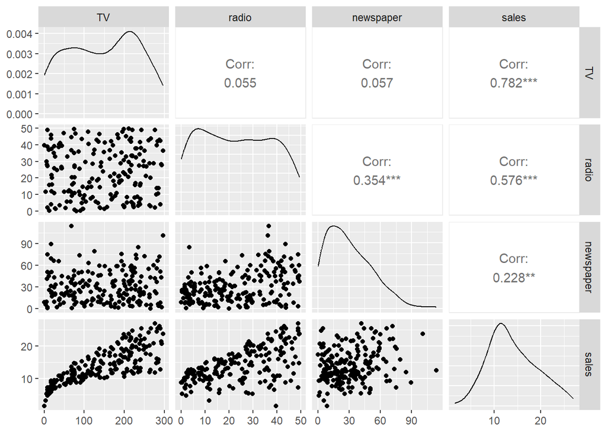

```r
library(GGally)


ggpairs(data = base %>% select(-X))
```

## Punto 2

Calcula una regresión simple utilizando como variable independiente alguna de las variables de gasto y como variable dependiente el valor de las ventas.

```r
reg <- lm(formula = sales ~ TV,
          data = base)

summary(reg)
```

```
Call:
lm(formula = sales ~ TV, data = base)

Residuals:
    Min      1Q  Median      3Q     Max
-8.3860 -1.9545 -0.1913  2.0671  7.2124

Coefficients:
            Estimate Std. Error t value Pr(>|t|)
(Intercept) 7.032594   0.457843   15.36   <2e-16 ***
TV          0.047537   0.002691   17.67   <2e-16 ***
---
Signif. codes:  0 '***' 0.001 '**' 0.01 '*' 0.05 '.' 0.1 ' ' 1

Residual standard error: 3.259 on 198 degrees of freedom
Multiple R-squared:  0.6119,    Adjusted R-squared:  0.6099
F-statistic: 312.1 on 1 and 198 DF,  p-value: < 2.2e-16
```

## Punto 3

Realiza un gráfico de dispersión con la recta de regresión utilizando las variables que utilizaste en el punto 2.

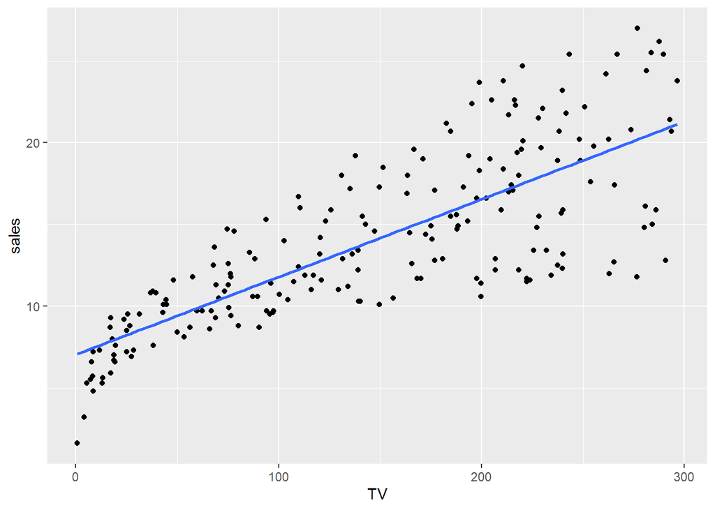

```r
base %>%
  ggplot(mapping = aes(x = TV, y = sales)) +
  geom_point() +
  geom_smooth(method = "lm",
              se = F)
```

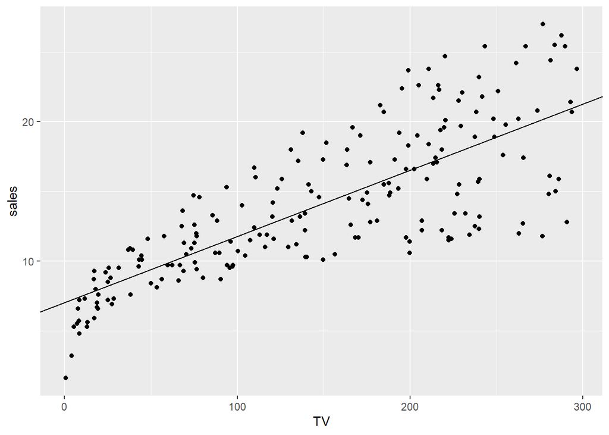

```r
base %>%
  ggplot(mapping = aes(x = TV, y = sales)) +
  geom_point() +
  geom_abline(intercept = reg$coefficients[1],
              slope = reg$coefficients[2])
```

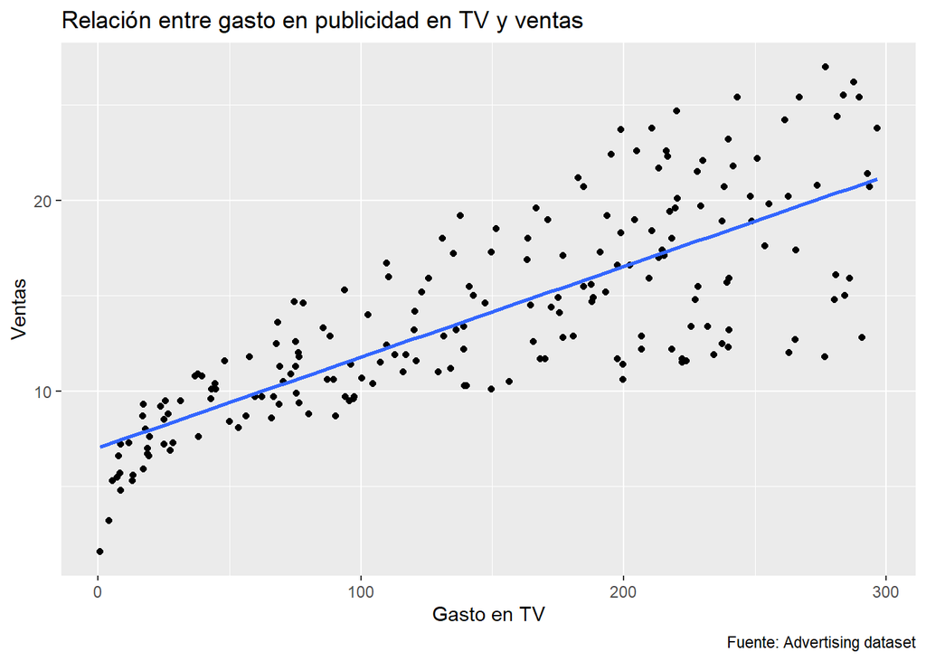

```r
g <- base %>%
  ggplot(mapping = aes(x = TV, y = sales)) +
  geom_point() +
  geom_smooth(method = "lm",
              se = F) +
  labs(title = "Relación entre gasto en publicidad en TV y ventas",
       x = "Gasto en TV",
       y = "Ventas",
       caption = "Fuente: Advertising dataset")

g
```

Comando para exportar gráficos de R en tu directorio de trabajo

```r
ggsave(filename = "graficoDispersion.png",  # Nombre del grafico
       plot = g,                            # Objeto
       dpi = 500,                           # Calidad
       width = 6,                           # Ancho
       height = 4)                          # Alto
```